# Coursework Report

*N* removed NAs: 2

*N* removed <18: 16

*N* total clean: 129

| Group | *N* | *M*<sub>age</sub> | *M*<sub>rating</sub> |
| --- | --- | --- | --- |
| Control | 64 | 20.6 | 5.63 |
| Experim | 65 | 21.2 | 6.77 |

**Main analysis results**

*t*(127) = -8.36, *p* < .001

# Coursework Report

Analysing Data, Spring 2020

# Methods

## Participants

Table 1: Descriptive statistics for participants by condition

| Condition | Count | Percentage (%) | *Mean*<sub>Age</sub> | *SD*<sub>Age</sub> | *Min*<sub>Age</sub> | *Max*<sub>Age</sub> |
| --- | --- | --- | --- | --- | --- | --- |
| White | 64 | 51.6 | 20.6 | 1.87 | 18 | 25 |
| Red | 60 | 48.4 | 20.7 | 1.77 | 18 | 25 |

## Design

This is a replication of Experiment 1 conducted by Elliot et al. (2010) which examined the effect of the colour red on women’s perceived attractiveness of men. It is hypothesised that women perceive men in conjunction with the colour red to be more attractive. In this independent group design, subjects were assigned to either the white condition (*n* = 64) or the red condition (*n* = 60). All subjects viewed the same man in a photograph, the colour of the frame of the photograph is the independent variable that is manipulated, the frame is white in the white condition and red in the red condition. All subjects then completed a 3-item questionnaire: “How attractive do you think this person is?”, “How pleasant is this person to look at?” and “If I were to meet the person in this picture face to face, I would think he is attractive.”. The subjects rated these 3 items on a 9-point rating scale, ranging from 1 (not at all attractive) to 9 (extremely attractive). These ratings are the dependent variables that measure the subjects’ perceived attractiveness of the man, higher ratings indicate greater perceived attractiveness and lower ratings indicate lower perceived attractiveness. It is predicted that ratings in the attractiveness questionnaire in the red condition in which subjects viewed the man in a photograph with red frame are higher than that in the white condition in which subjects viewed the man in a photograph with a white frame. An independent t-test is used to test the hypothesis.

# Results

The composite index (CI), which is the mean rating for all 3 items in the questionnaire, is calculated for each subject and the mean CI for the conditions are compared. A plot (Figure 1) is used to show the mean CIs and confidence intervals for the white and the red condition. The grey and red points represent the mean CI for the white and the red condition respectively and the error bars represent 95% confidence intervals. It is observed that the mean CI for the red condition (*M* = 6.82, *SD* = 0.82) is higher than that for the white condition (*M* = 5.63, *SD* = 0.71). This indicates that subjects perceived the man in the photograph with a red frame to be more attractive than the same man in the photograph with a white frame. Statistical analysis indicated a significant effect of the colour red on women’s perceived attractiveness of the man (*M*<sub>diff</sub> = 1.19, 95% CI [-1.46, -0.91], *t*(122) = -8.61, *p* < .001).

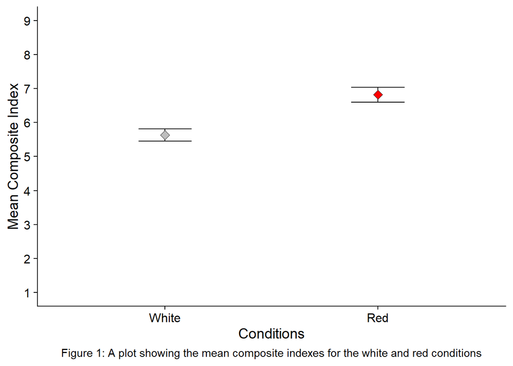

# Discussion

This study attempted to replicate experiment 1 from the original study (Elliot et al., 2010) which found a significant red-attractiveness effect for women. Results indicate that women perceived the man in conjunction with the colour red to be more attractive than the man in conjunction with the colour white. Therefore, this study has replicated findings from Experiment 1 from the original study and supports the red-attractiveness effect for women. Similar results were also found in the remaining 4 replications in the original study which involved using grey, green or blue as control colours. This is also consistent with Roberts, Owen, and Havlicek (2010), they relied on a within-subjects design and also found a significant red-attractiveness effect for women when compared to blue, green, yellow and white but not black, demonstrating the superiority of the colour red. Overall, the red-attractiveness effect for women has strong empirical support.

Francis (2013) criticised Elliot et al. (2010) for their experiments having inadequate statistical power due to small sample sizes and, accordingly, should be prone to type II error. However, consistent reports of statistical significance across the experiments led to the suspicion of publication bias. Using the Ioannidis and Trikalinos test for publication bias (Ioannidis & Trikalinos, 2007a), Francis (2013) found evidence for it in the set of replications examining the red-attractiveness effect. Elliot and Maier (2013) responded by referring back to Ioannidis and Trikalinos (2007a, 2007b) highlighting that the test should be used with caution and is intended for assessing publication bias in large meta-analyses or multiple meta-analyses, thereby, arguing for the improper use of the test. Elliot and Maier (2013) addressed the issue regarding publication bias and the inadequacy of power by attempting to replicate Experiment 3 with a larger sample size, they found a small but not significant effect in the predicted direction. Nevertheless, based on their replication attempt and supportive replications from other independent studies, they stood with the red-attractiveness effect and suggested that the effect size may be small, thus requires an even bigger power.

Although they have somewhat addressed the issue regarding the power of their experiments, they did not adequately address the issue regarding publication bias because the replication attempt was conducted by the same researchers. In addition, the “replications” from other studies they have used for evidence employed different paradigms and methodologies, therefore, they are not strict replications, possible extraneous variables may have led to the same outcome. This current replication employed the same paradigm and methodology used in the original experiment, has higher power and is independent to the original researchers, therefore, it provides stronger evidence for the red-attractiveness effect for women than previous “replications” and the replication attempt by Elliot and Maier (2013).

One limitation of this replication is that it did not examine the effect size. Effect size is another important aspect that affects the power of experiments, thus the accuracy of results. However, this replication does not contribute to this aspect of research. Previous pioneering studies found a large effect (Elliot et al., 2010; Roberts et al., 2010). However, later studies and replications suggest smaller effect sizes. For example, the aforementioned replication (Elliot & Maier, 2013) found a small effect in the predicted direction. Hesslinger, Goldbach, and Carbon (2015) attempted to replicate Experiment 3 with a larger sample size and found a null effect despite having a power of 0.978 based on the effect size found by Elliot et al. (2010). These studies suggest that the effect size may be smaller than that found by pioneering studies. More recent replications even found a small effect in the opposite direction. For example, Lehmann and Carlin-Jageman (2017) conducted a close replication of Experiment 1 with 360 female subjects and found a negative but not significant effect. Wagge, Baciu, Banas, Nadler, and Schwarz (2019) meta-analysed students’ replication of Experiment 3 through the Collaborative Replication and Education Project involving a total of 640 female subjects and also found a negative but not significant effect. These two studies were preregistered and results were based on large sample sizes. With such scientific integrity and high power, they provide strong evidence against the red-attractiveness effect for women. Overall, there are inconsistencies in the significance and effect size and direction.

Lehmann, Elliot, and Carlin-Jageman (2018) meta-analysed 36 studies examining the red-attractiveness effect for women that were conducted between 2010 and 2017, they found an overall small and significant effect in the hypothesised direction. Perhaps more interestingly, they found a tendency for preregistered studies to report smaller effect sizes than non-preregistered studies, a trend for published studies to report bigger effect sizes than unpublished studies and a decline effect (Schooler, 2011), which is the tendency for the effect size to decrease (and become negative) throughout the years. The authors concluded that the red-attractiveness effect for women may have been exaggerated by pioneering studies and suggested that the effect size may be small and the effect is potentially non-existent. One possibility for these findings is publication or reporting biases in early studies that have exaggerated the red-attractiveness effect (Francis, 2013; Lehmann et al., 2018). The replication crisis and increasing awareness of biases in research may have resulted in more researchers preregistering their studies, which may have contributed to less significant findings. Another possibility is that the red-attractiveness effect may be a temporally unstable phenomenon, that is, the effect size was, in fact, large when it was first discovered but gradually diminishes across time and in turn becomes negative.

Although this present replication did not examine the effect size, based on the available statistics, the effect size is estimated to be large. This is consistent with and supports pioneering studies, but is not in line with the aforementioned recent evidence and may be an outlier in the literature. A possible explanation for such variable outcomes may be factors that moderate the red-attractiveness effect. For example, the red-derogation effect (Pontes & Hoegg, 2019), which extends from intimate relationship theories, postulates that given that the red-attractiveness effect is true, the attractiveness-enhancing effect of the colour red promotes threat to intimate relationships, partners attempt to protect their intimate relationships from such threat by employing relationship maintenance strategies, which includes giving lower attractiveness ratings. Regardless of the underlying cognitive mechanism, Pontes and Hoegg (2019) demonstrated that the colour red suppressed married women’s perceived attractiveness of men. This implies that relationship or marital statuses modulate the red-attractiveness effect. Pioneering studies based their findings on subjects within low and narrow age ranges, subjects within such age ranges are unlikely to be in a relationship or married, therefore, results are less likely to be impacted by the red-derogation effect. However, most previous studies involve subjects from wider age ranges (e.g. Hesslinger et al., 2015; Wagge et al., 2019), subjects from wide age ranges are more likely to be in a relationship or married, therefore, the red derogation may have impacted the results and contributed to null or even negative effects.

Apart from relationship or marital statuses, there may be other modulators. Young (2015) found that the colour red only enhanced women’s perceived attractiveness of men who were pre-rated as attractive but not those who were pre-rated as unattractive, suggesting that the baseline attractiveness may be another modulator of the red-attractiveness effect. These findings suggest that the red-attractiveness can be modulated by various factors and results can vary depending on the modulators. These modulators were not controlled in previous studies and may have contributed to highly variable findings.

In conclusion, this study found a significant and positive effect of the colour red on women’s perceived attractiveness of men, therefore, it has replicated findings from the original study, providing support for the red-attractiveness effect for women. In addition, the effect size is estimated to be very large, which is an outlier in the literature. Overall, there are inconsistencies in the significance and effect size and direction reported across studies in the literature, meaning that there are still uncertainties in the red-attractiveness effect for women. These inconsistencies may be due to the differences in the power of experiments, temporal instability of the phenomenon, publication and reporting biases, the level of control and the impacts of modulators. More replications and studies in the future are required to test the reliability of this replication and to explore possible modulators respectively. Improvements can be made in future studies. Firstly, researchers should conduct replications as close to the original study as possible to maintain high levels of control to reduce extraneous effects. Secondly, large sample sizes should be used to ensure adequate statistical power. Sample sizes as big as 930 participants per group in a between-sample design may be needed (Lehmann et al., 2018), this can be more practically achieved by using a within-sample design and having collaborations between multiple studies. Thirdly, researchers should preregister their studies to avoid biases and postdictions (Nosek, Ebersole, DeHaven, and Mellor, 2018). Finally, when modulators are identified, a change in the methodology may be needed in order to control or systematically investigate the effects of different moderators.

# References

Elliot, A. J., Niesta Kayser, D., Greitemeyer, T., Lichtenfeld, S., Gramzow, R. H., Maier, M. A., & Liu, H. (2010). Red, rank, and romance in women viewing men. *Journal of*

Experimental Psychology: General, 139(3), 399–417. doi: 10.1037/a0019689

Elliot, A. J., & Maier, M. A. (2013). The red-attractiveness effect, applying the Ioannidis and Trikalinos (2007b) test, and the broader scientific context: A reply to Francis (2013). *Journal of Experimental Psychology: General, 142*(1), 297–300. doi: 10.1037/a0029592

Francis, G. (2013). Publication bias in “Red, rank, and romance in women viewing men,” by Elliot et al. (2010). *Journal of Experimental Psychology: General, 142*(1), 292–296. doi: 10.1037/a0027923

Hesslinger, V. M., Goldbach, L., & Carbon, C.-C. (2015). Men in red: A reexamination of the red-attractiveness effect. *Psychonomic Bulletin & Review, 22*(4), 1142–1148. doi: 10.3758/s13423-015-0866-8

Ioannidis, J. P., & Trikalinos, T. A. (2007). An exploratory test for an excess of significant findings. *Clinical Trials, 4*(3), 245–253. doi: 10.1177/1740774507079441

Ioannidis, J. P., & Trikalinos, T. A. (2007). Authors’ response to V Johnson and Y Yuan. *Clinical Trials, 4*(3), 256–257. doi: 10.1177/1740774507079433

Lehmann, G. K., & Calin-Jageman, R. J. (2017). Is Red Really Romantic?: Two Pre-Registered Replications of the Red-Romance Hypothesis. *Social Psychology, 48*(3), 174–183. doi: 10.1027/1864-9335/a000296

Lehmann, G. K., Elliot, A. J., & Calin-Jageman, R. J. (2018). Meta-Analysis of the Effect of Red on Perceived Attractiveness. *Evolutionary Psychology, 16*(4). doi: 10.1177/1474704918802412

Nosek, B. A., Ebersole, C. R., DeHaven, A. C., & Mellor, D. T. (2018). The preregistration revolution. *Proceedings of the National Academy of Sciences, 115*(11), 2600–2606. doi: 10.1073/pnas.1708274114

Pontes, N., & Hoegg, J. (2019). The red-derogation effect: How the color red affects married women’s ratings of male attractiveness. *Journal of Experimental Psychology: Applied*. doi: 10.1037/xap0000256

Roberts, S. C., Owen, R. C., & Havlicek, J. (2010). Distinguishing between Perceiver and Wearer Effects in Clothing Color-Associated Attributions. *Evolutionary Psychology, 8*(3), 350–364. doi: 10.1177/147470491000800304

Schooler, J. (2011). Unpublished results hide the decline effect. *Nature, 470*, 437–437. doi: 10.1038/470437a

Wagge, J. R., Baciu, C., Banas, K., Nadler, J. T., Schwarz, S., Weisberg, Y., … Grahe, J. (2019). A Demonstration of the Collaborative Replication and Education Project: Replication Attempts of the Red-Romance Effect. *Collabra: Psychology, 5*(1), 5. doi: 10.1525/collabra.177

Young, S. G. (2015). The effect of red on male perceptions of female attractiveness: Moderation by baseline attractiveness of female faces. *European Journal of Social Psychology, 45*(2), 146–151. doi: 10.1002/ejsp.2098